# Group Assignment1-MLM

Kalyango Jovan, Lale, Lina

14/02/2022

## 1

The multilevel analysis(modeling) is used statistical analysis of data have a hierarchical or clustered structure. Such data are educational, for instance students are nested within schools. It is worth highlighting that data within same cluster(e.g school) are more similar than data across different clusters hence, the independence assumption is violated, yet Standard statistical tests are not at all robust against violation of the independence assumption. But also,the degree of similarity is indicated by the intraclass correlation $\rho$.

By ignoring the structure of the data and disaggregate the school-level(second-level) we can perform the conventional regression analysis, violates the independent assumption among observations. This is due to the fact that students from the same school are more likely to have similar scores than students from different schools, in other words they are dependent to each other, if the school they come from is the same. The problem of violating the assumption, is underestimation of the standard errors and this leads to inflated type I error rate. By not deploying multilevel analysis, may result in violation of other assumptions like linearity, presence of outlier and others.

On another hand, if we choose to aggregate the lower level(students) to second- level( school-level) will lead to a substantial decrease in the effective sample size hence lowering the statistical power[@hox2017multilevel]. So, performing, mulmtilevel analysis allows a proper assessment of effects of LRT-score on the outcome variable (Examscore) accross schools(clustrs), avarage score can be used to asses if partly affect the Examscore between schools.

To sum up, the available information from the dataset, we theoretically think it is appropriate to use multilevel analysis in this case.

# 2

## Discriptive Statistics

We can view some descriptive statistics with $summary()$. where the minimum and maximum are respectively the first and last values in the output below for each variable. Alternatively,we can compute them by using with the $min()$ and $max()$ functions. Also, the function $summary()$ gives other four quantities(mean, median, first and third quartiles).

```r
summary(exam)
```

```
##    ï..School        Student        Examscore            LRTscore
##  Min.   : 1.00   Min.   :  1.0   Min.   :-3.666100   Min.   :-2.93500
##  1st Qu.:14.00   1st Qu.: 16.0   1st Qu.:-0.699510   1st Qu.:-0.62071
##  Median :29.00   Median : 33.0   Median : 0.004322   Median : 0.04050
##  Mean   :31.01   Mean   : 38.7   Mean   :-0.000118   Mean   : 0.00181
##  3rd Qu.:47.00   3rd Qu.: 54.0   3rd Qu.: 0.678760   3rd Qu.: 0.61906
##  Max.   :65.00   Max.   :198.0   Max.   : 3.666100   Max.   : 3.01600
##      AvsLRT
##  Min.   :-0.755960
##  1st Qu.:-0.149340
##  Median :-0.020198
##  Mean   : 0.001811
##  3rd Qu.: 0.210520
##  Max.   : 0.637660
```

## Outlier checking

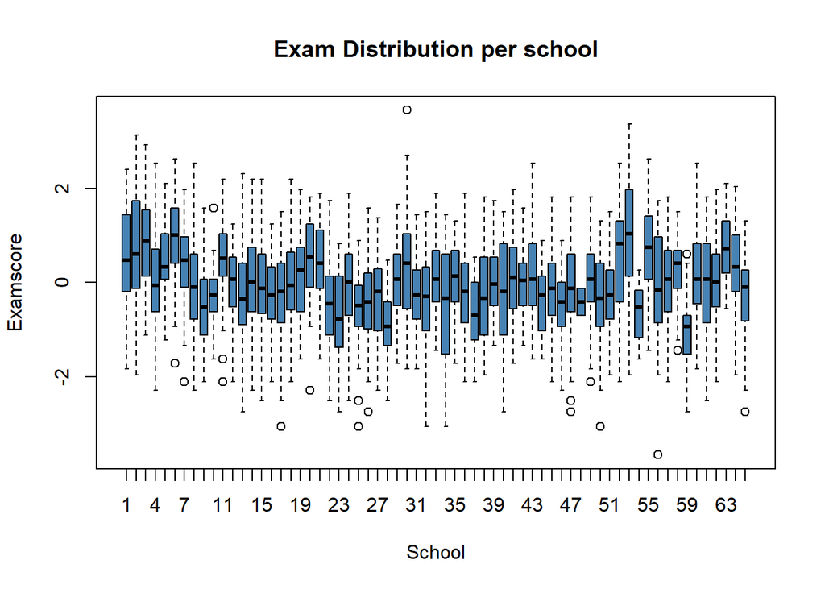

```r
#create boxplot that displays examscore distribution for each school in the dataset
boxplot(Examscore~ï..School,
data= exam,
main="Exam Distribution per school",
xlab="School",
ylab="Examscore",
col="steelblue",
border="black"
)
```

# 3

# a)

Yes, because we use multilevel regression analysis to accommodate nested data and the dataset we are given is nested, the dataset is of hierarchical structure.

# b)

H0: $u_{0j}=0$  
vs  
HA: $u_{0j}>0$

Or by means of diviance

H0: Deviance of the null/baseline model is equal to the deviance of intercept model;
$$Deviance_{m0} = Deviance_{m1}$$

Vs

H1: Deviance of the null/baseline model is larger than the deviance of intercept model;
$$Deviance_{m0}> Deviance_{m1}$$